# w02-hw-syang118

Seonhye Yang, NetID: syang118

5/26/2019

```r
library(MASS)
```

##Exercise 1 (Using lm)

```r
#a
cat_model <- lm(Hwt~Bwt, data = cats)
summary(cat_model)
```

```
##
## Call:
## lm(formula = Hwt ~ Bwt, data = cats)
##
## Residuals:
##     Min      1Q  Median      3Q     Max
## -3.5694 -0.9634 -0.0921  1.0426  5.1238
##
## Coefficients:
##             Estimate Std. Error t value Pr(>|t|)
## (Intercept)  -0.3567     0.6923  -0.515    0.607
## Bwt           4.0341     0.2503  16.119   <2e-16 ***
## ---
## Signif. codes:  0 '***' 0.001 '**' 0.01 '*' 0.05 '.' 0.1 ' ' 1
##
## Residual standard error: 1.452 on 142 degrees of freedom
## Multiple R-squared:  0.6466, Adjusted R-squared:  0.6441
## F-statistic: 259.8 on 1 and 142 DF,  p-value: < 2.2e-16
```

```r
#b
```

$\hat{\beta}_0 = -0.3567$ and $\hat{\beta_1} = 4.0341$. As body weight increases by one unit, heart weight increases by 4.0341 grams.

```r
#c
predict(cat_model, data.frame(Bwt = 2.7))
```

```
##        1
## 10.53531
```

```r
#We get a prediction of 10.53531 grams and we are quite confident in our prediction because 2.7 ranges within the data cats.
```

```r
#d
predict(cat_model, data.frame(Bwt = 4.4))
```

```
##        1
## 17.39321
```

```r
#Unlike the problem above, this prediction, 17.39321, is not as confident because body weight 4.4kg is outside of the data range.
```

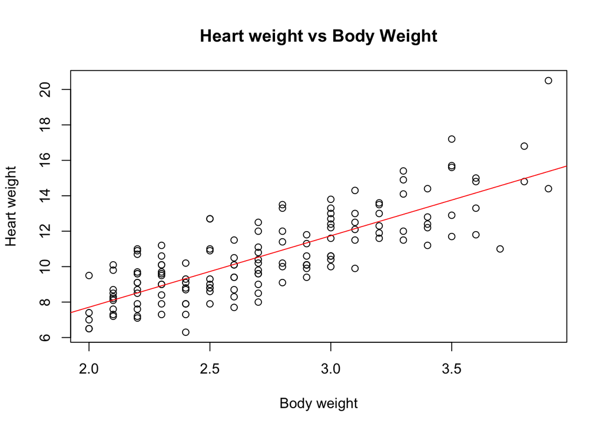

```r
#e
plot(Hwt~Bwt,data = cats, main = "Heart weight vs Body Weight", xlab = "Body weight", ylab = "Heart weight")
abline(lm(Hwt~Bwt, data = cats), col = "red", )
```

```r
#f
summary(cat_model)$r.squared
```

```
## [1] 0.6466209
```

R-squared = 0.6466 which indicates that 64.66% of the observed variation in heart weight is explained by the linear relationship.

##Exercise 2 (Writing Functions)

```r
#a
get_sd_est = function(fitted_vals, actual_vals, mle = F)
  {
n = length(fitted_vals) - 2 * isFALSE(mle) #-2 is for the degree of freedom
sqrt(sum((actual_vals - fitted_vals)^2)*1/n) #This indicates the RMSE
}
```

```r
#b
get_sd_est(fitted_vals = fitted(cat_model), actual_vals = cats$Hwt)
```

```
## [1] 1.452373
```

We get a standard error of 1.452373 which means when estimating the cat’s heart weight, the weight will be off by 1.452373g.

```r
#c
get_sd_est(fitted_vals = fitted(cat_model), actual_vals = cats$Hwt, mle = T)
```

```
## [1] 1.442252
```

We get a standard deviation of 1.442252 which means when estimating the cat’s heart weight, the weight will be off by 1.442252g.

```r
summary(cat_model)$sigma
```

```
## [1] 1.452373
```

##Exercise 3 (Simulating SLR)

```r
birthday = 18760613
set.seed(birthday)

#a
x = runif(n = 25, 0, 10)

sim_slr = function(x, beta_0 = 10, beta_1 = 5, sigma = 1) {
  n = length(x)
  epsilon = rnorm(n, mean = 0, sd = sigma)
  y = beta_0 + beta_1 * x + epsilon
  data.frame(predictor = x, response = y)
}

set.seed(1)
sim_data = sim_slr(x = x, beta_0 = 5, beta_1 = -3, sigma = sqrt(10.24))
```

```r
#b
model_sim <- lm(sim_data$response~sim_data$predictor)
summary(model_sim)
```

```
##
## Call:
## lm(formula = sim_data$response ~ sim_data$predictor)
##
## Residuals:
##     Min      1Q  Median      3Q     Max
## -7.6563 -1.5746  0.8989  1.6005  4.7425
##
## Coefficients:
##                    Estimate Std. Error t value Pr(>|t|)
## (Intercept)          4.9451     1.3109   3.772 0.000988 ***
## sim_data$predictor  -2.8732     0.2465 -11.657 3.93e-11 ***
## ---
## Signif. codes:  0 '***' 0.001 '**' 0.01 '*' 0.05 '.' 0.1 ' ' 1
##
## Residual standard error: 3.088 on 23 degrees of freedom
## Multiple R-squared:  0.8552, Adjusted R-squared:  0.8489
## F-statistic: 135.9 on 1 and 23 DF,  p-value: 3.934e-11
```

Here we get an intercept $\beta_0 = 4.9451$ and slope $\beta_1 = -2.8732$. The values we got are somewhat close to the original intercept (5) and slope (-3) respectively.

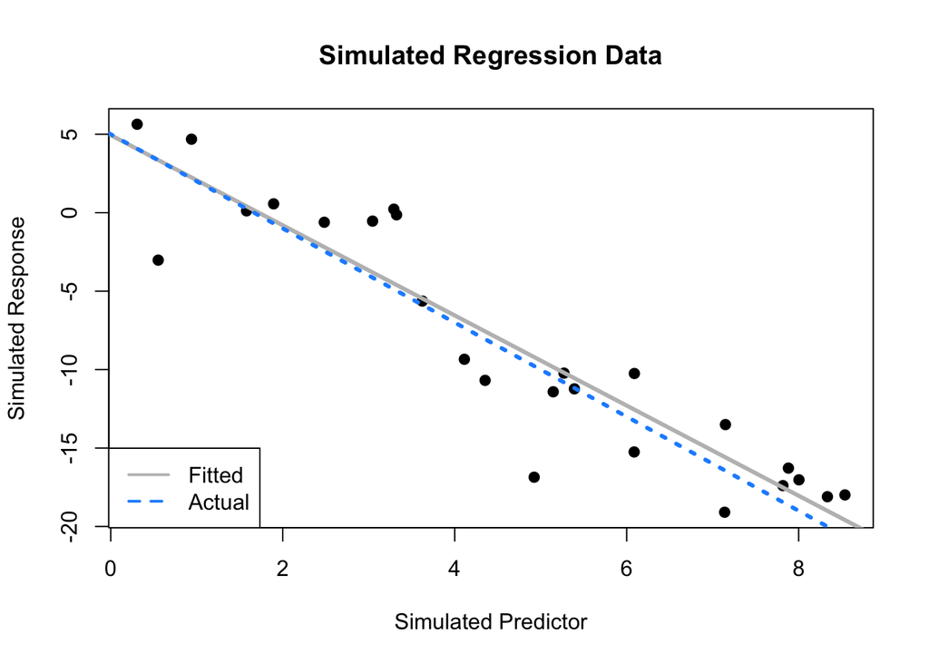

```r
plot(sim_data,
     main = "Simulated Regression Data",
     xlab = "Simulated Predictor",
     ylab = "Simulated Response",
     pch = 20,
     cex = 1.5,
     col = "black")
abline(model_sim,
       lwd = 3,
       lty = 1,
       col = "grey")
abline(5, -3,
       lwd = 3,
       lty = 3,
       col = "dodgerblue")
legend("bottomleft", c("Fitted", "Actual"), lwd = 2, lty = c(1, 2),
col = c("grey", "dodgerblue"))
```

```r
#d
beta_hat_1 = rep(0, 1500)
for (i in seq(beta_hat_1))
{sim_data = sim_slr(x, beta_0 = 5, beta_1 = -3, sigma = sqrt(10.24))
model_sim <- lm(sim_data$response~sim_data$predictor)
beta_hat_1[i] = model_sim$coefficients[2]}
```

```r
#e
mean(beta_hat_1)
```

```
## [1] -3.011265
```

```r
sd(beta_hat_1)
```

```
## [1] 0.2607453
```

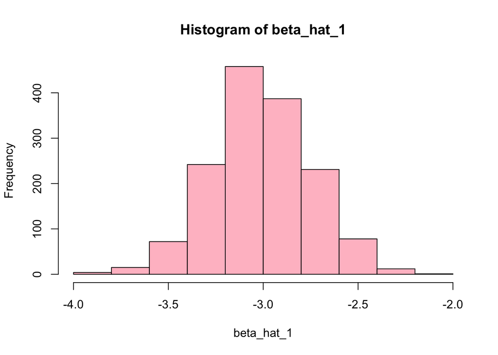

```r
hist(beta_hat_1,
     main = "Histogram of beta_hat_1",
     xlab = "beta_hat_1",
     col = "pink")
```

The histogram represents somewhat a normal distribution with $\mu = -3$

##Exercise 4 (Be a Skeptic)

```r
#a
birthday = 18760613
set.seed(birthday)

x = runif(n = 75, 0, 10)

beta_hat_1 = rep(0, 2500)
for (i in seq(beta_hat_1))
{sim_data = sim_slr(x = x, beta_0 = 3, beta_1 = 0, sigma = sqrt(4))
model_sim_1 <- lm(sim_data$response~sim_data$predictor)
beta_hat_1[i] = model_sim_1$coefficients[2]}
```

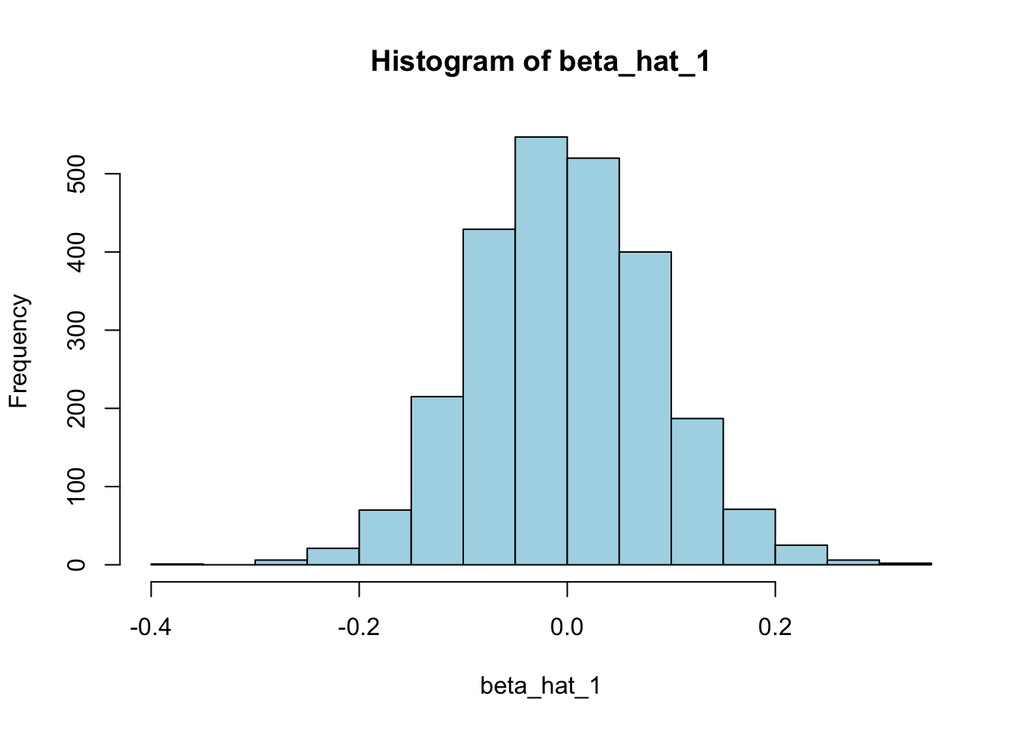

```r
#b
hist(beta_hat_1,
     main = "Histogram of beta_hat_1",
     xlab = "beta_hat_1",
     col = "light blue")
```

The histogram represents somewhat a normal distribution with $\mu = 0$

```r
#c
skeptic <- read.csv("~/Desktop/w02-hw-syang118/skeptic.csv")
lm(response~predictor, data = skeptic)
```

```
##
## Call:
## lm(formula = response ~ predictor, data = skeptic)
##
## Coefficients:
## (Intercept)    predictor
##      3.1504      -0.2222
```

```r
set.seed(100)
x = runif(n = 75, 0, 10)
skeptics = sim_slr(x, beta_0 = 3.15, beta_1 = -0.22, sigma = 1)
skeptic_model = lm(skeptic$response ~ skeptic$predictor)
skeptic_model$coefficients
```

```
##       (Intercept) skeptic$predictor
##         3.1504230        -0.2221927
```

We get a predictor value of -0.2221927.

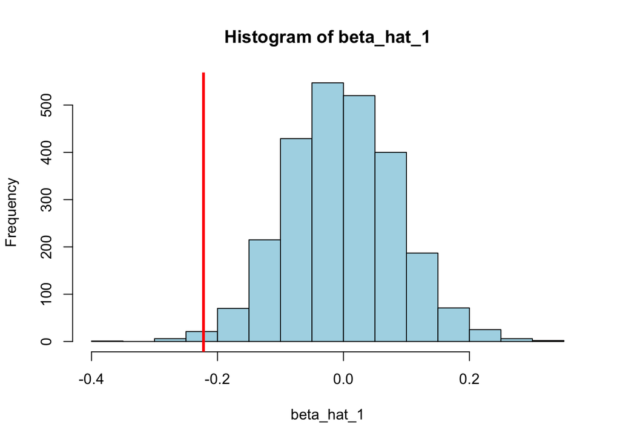

```r
#d
hist(beta_hat_1,
     main = "Histogram of beta_hat_1",
     xlab = "beta_hat_1",
     col = "light blue")
abline(v = skeptic_model$coefficients[2], lwd = 3, col = "red")
```

```r
#e
value<-beta_hat_1 < skeptic_model$coefficients[2]
mean(value)
```

```
## [1] 0.0052
```

```r
#0.0052 of the portion is smaller than our beta_hat_1.
2*mean(value)
```

```
## [1] 0.0104
```

```r
#0.0104 is when we multiply by 2 and mean(value)
```

```r
#f
#We can look at the ranges of beta_hat_1
range(beta_hat_1)
```

```
## [1] -0.3596241  0.3022105
```

Beta_hat_1 ranges from -0.3596241 to 0.3022105. Although our predictor = -0.222 is within the range of beta_hat_1, there’s a low probablity that skeptics.csv data could have been generated by the model given above. This is because if we look at the output from question $e$, $0.0052$ or $0.52%$ of the simulated values are smaller than our predictor = -0.222. In conclusion it’s possible that it was generated by the simulation but low probablity.

##Exercise 5

```r
library(mlbench)
data(Ozone, package = "mlbench")
Ozone = Ozone[, c(4, 6, 7, 8)]
colnames(Ozone) = c("ozone", "wind", "humidity", "temp")
Ozone = Ozone[complete.cases(Ozone), ]
```

```r
#a
attach(Ozone, warn.conflicts = F)
#models
slr_wind <- lm(ozone~wind)
slr_humidity <- lm(ozone~humidity)
slr_temp <- lm(ozone~temp)

#Calculating RMSE and R^2
RMSE = function(list_of_slr){
  sqrt(mean(residuals(list_of_slr)^2))}

r_2 = function(list_of_slr) {summary(list_of_slr)$r.squared}

list_of_slr = list(slr_wind, slr_humidity, slr_temp)

cbind(lapply(list_of_slr, RMSE))
```

```
##      [,1]
## [1,] 7.961695
## [2,] 7.147822
## [3,] 5.009257
```

```r
cbind(lapply(list_of_slr, r_2))
```

```
##      [,1]
## [1,] 0.000140193
## [2,] 0.1941105
## [3,] 0.6042011
```

```r
#b
library(knitr)
output <- data.frame(
  Predictors = c("Wind", "Humidity", "Temperature"),
  RMSE = cbind(lapply(list_of_slr, RMSE)),
  r_2 = cbind(lapply(list_of_slr, r_2)))
kable(head(output), caption = "table of models")
```

table of models

| Predictors | RMSE | r_2 |
| --- | --- | --- |
| Wind | 7.96169520147809 | 0.000140193043547608 |
| Humidity | 7.14782233822989 | 0.194110467873961 |
| Temperature | 5.00925694800056 | 0.60420105314034 |

```r
#According to the table, temperature is the best predictor because it has the lowest RMSE
```